# Take Home Final: SDS II

Author

Brandy Carr

**Notes:**

- 1: Please read all instructions for each question carefully.
- 2: All models can be constructed using the methods we learned this semester (Dr. Seals has double checked everything… she thinks 😅). Some questions are *intentionally* challenging to simulate a “real life” working environment where we have to research solutions to issues.
- 3: Coding-specific notes:
  - If you get an error about a model not converging, please look into increasing the number of iterations for the function you are using.
  - If a function suddenly does not work as it previously did on a project, Google the error message.
  - The following functions may be helpful when you need some data management help: `mutate()`, `as.numeric()`, `if_else()`, and/or `case_when()`.
- 4: Formatting notes:
  - Please do not bold your responses - make it easy for me to tell the difference between my questions and your responses.
  - Do not print the dataset to the file; if you want to view the dataset, please use the data viewer in RStudio or use the `head()` function. (Do not make me scroll forever to find your answer… I may overlook it on accident.)
- 4: You are not permitted to discuss the content of this exam with anyone other than Dr. Seals. *Evidence of acaademic misconduct will be submitted to the Dean of Students office and you will receive a 0 on this exam.*

## Dataset 1: Spotify

**1. Consider the Spotify data here: [TidyTuesday - Spotify](https://github.com/rfordatascience/tidytuesday/tree/master/data/2020/2020-01-21). We will be working with *danceability* as the outcome and *loudness*, *energy*, and *playlist_genre* as predictors. Go ahead and pull in the data.**

```r
library(tidyverse)

spotify <- readr::read_csv('https://raw.githubusercontent.com/rfordatascience/tidytuesday/master/data/2020/2020-01-21/spotify_songs.csv')

spotify <- spotify %>%
  select(danceability, loudness, energy, playlist_genre) %>%
  mutate(playlist_genre = as.factor(playlist_genre))
```

**1a-i. Let’s do some data exploration. What are the possible responses in *playlist_genre*? How many songs fall into each genre?**

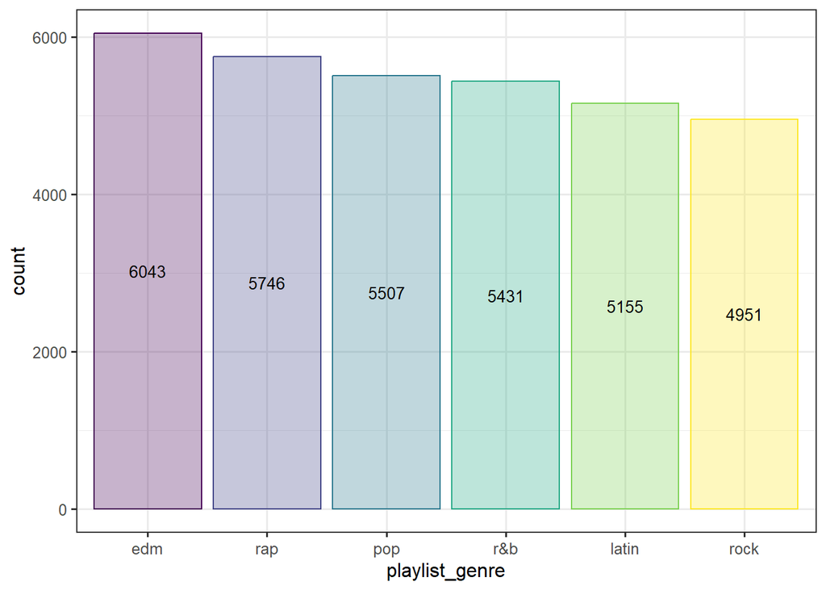

```r
playlist_genre_RANKED <- count(spotify, playlist_genre, sort=T)

spotify %>%
  mutate(playlist_genre = factor(playlist_genre, levels = playlist_genre_RANKED$playlist_genre, ordered=T)) %>%
  ggplot(aes(playlist_genre, col=playlist_genre, fill=playlist_genre)) +
  geom_bar(alpha=0.3) +
  stat_count(geom="text",
             col="black",
             size=3.5,
             position=position_stack(vjust=0.5),
             aes(label=after_stat(count))) +
  theme_bw(base_size=12) +
  theme(legend.position="none")
```

**1a-ii. Let’s do some data exploration. What is the mean *danceability*, *loudness*, and *energy* for each level of *playlist_genre*?**

```r
library(kableExtra)

spotify %>%
  group_by(playlist_genre) %>%
  summarise_all(., mean) %>%
  kable(align=rep("c",4)) %>%
  kable_paper()
```

| playlist_genre | danceability | loudness | energy |
| --- | --- | --- | --- |
| edm | 0.6550409 | -5.427445 | 0.8024759 |
| latin | 0.7132873 | -6.264455 | 0.7083125 |
| pop | 0.6393017 | -6.315328 | 0.7010278 |
| r&b | 0.6701793 | -7.864848 | 0.5909343 |
| rap | 0.7183528 | -7.042269 | 0.6507084 |
| rock | 0.5205480 | -7.588895 | 0.7328133 |

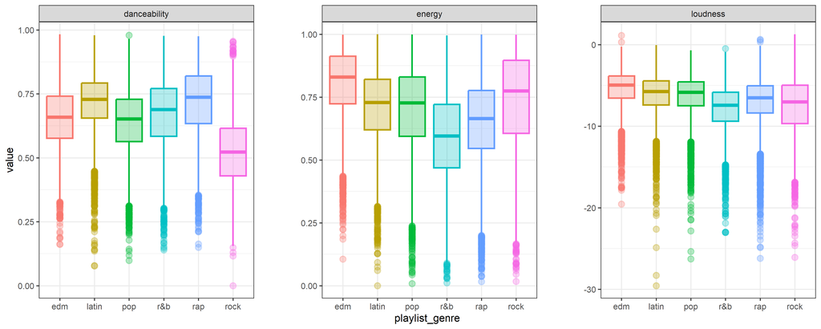

```r
spotify %>%
  pivot_longer(cols=danceability:energy) %>%
  filter(value > -30) %>%
  group_by(playlist_genre, name) %>%
  ggplot(aes(x=playlist_genre, y=value, group=playlist_genre, col=playlist_genre, fill=playlist_genre)) +
  geom_boxplot(alpha=0.3) +
  theme_bw(base_size=6.5) +
  theme(legend.position="none", panel.spacing.x=unit(2,"lines")) +
  facet_wrap(name~., scales="free")
```

**1b. Consider modeling *danceability* as a function of *loudness*, *energy*, *playlist_genre*, and the interaction between *loudness* and *energy*.**

**1b-i. What method (distribution) do you think is appropriate to apply here? Provide evidence to support your idea.**

```r
# danceability - Normal Histogram
par(mfrow=c(1,1), mar=c(5,5,4,2))
rcompanion::plotNormalHistogram(spotify$danceability,
                                prob=F,
                                xlab="danceability",
                                main="Normal Histogram of danceability",
                                linecol=1,
                                xlim=c(0,1))
box(which="figure", col="lightgray")


# danceability by genre - Normal Histogram's
genres <- as.character(playlist_genre_RANKED$playlist_genre)

normHist_FUN <- function(i){
  rcompanion::plotNormalHistogram(spotify$danceability[spotify$playlist_genre==genres[i]],
                                  prob=T,
                                  xaxt="n", yaxt="n",
                                  ylab="", xlab="",
                                  col=rainbow(6,alpha=0.3)[i],
                                  border=colorspace::darken(rainbow(6)[i], 0.2),
                                  linecol=1,
                                  xlim=c(0,1))
  text(x=0.03, y=1.5, labels=genres[i], col=colorspace::darken(rainbow(6)[i], 0.3), cex=2, adj=c(0,0.5))
}

par(mfrow=c(3,2), mar=c(3,3,3,3))
for(i in 1:6){
  normHist_FUN(i)
  box(which="figure", col="lightgray")
  }
```

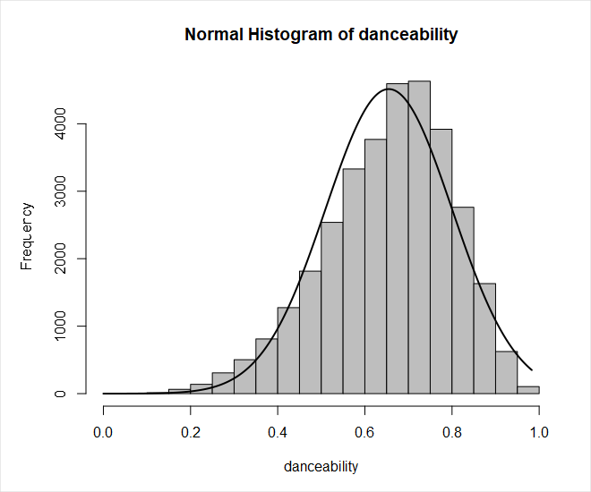

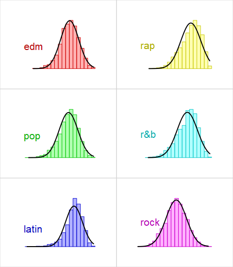

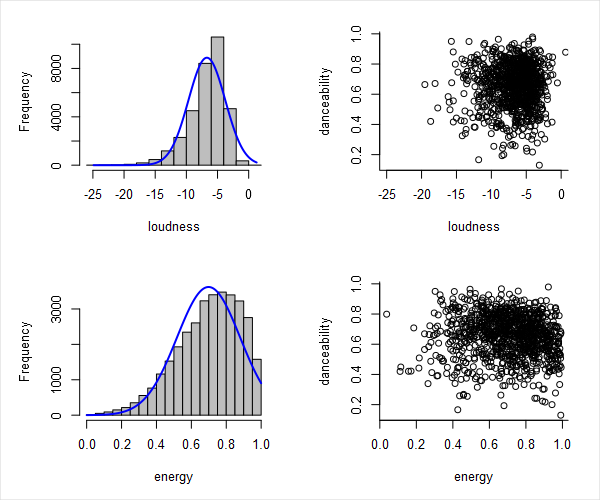

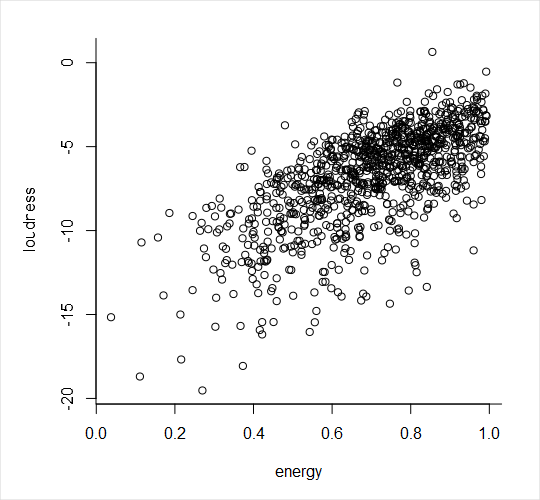

```r
# normal histogram's of loudness & energy
# scatterplots of loudness & energy ~ danceability
set.seed(1000)
i = sample(1:nrow(spotify), 1000)
par(mfrow=c(2,2), mar=c(5,5,2,2))
rcompanion::plotNormalHistogram(spotify$loudness[spotify$loudness >= -25], xlab="loudness")
plot(spotify$danceability[i] ~ spotify$loudness[i], xlim=c(-25,0), xlab="loudness", ylab="danceability")
rcompanion::plotNormalHistogram(spotify$energy, xlab="energy")
plot(spotify$danceability[i] ~ spotify$energy[i], xlab="energy", ylab="danceability")
box(which="outer", col="lightgray")


# scatterplot of loudness ~ energy
par(mfrow=c(1,1), mar=c(5,5,2,2))
plot(spotify$loudness[i] ~ spotify$energy[i],
     xlab="energy",
     ylab="loudness")
box(which="outer", col="lightgray")
```

**1b-ii. What is the resulting model using the approach from 1b-i?**

```r
spotify_reduced <- glm(danceability ~ 1, data=spotify)
spotify_full <- glm(danceability ~ loudness + energy + playlist_genre + loudness:energy, data=spotify)

summary(spotify_full)
```

```
Call:
glm(formula = danceability ~ loudness + energy + playlist_genre +
    loudness:energy, data = spotify)

Coefficients:
                      Estimate Std. Error t value Pr(>|t|)
(Intercept)          0.8325599  0.0080534 103.380   <2e-16 ***
loudness             0.0169693  0.0006925  24.503   <2e-16 ***
energy              -0.2423924  0.0095404 -25.407   <2e-16 ***
playlist_genrelatin  0.0486637  0.0024922  19.526   <2e-16 ***
playlist_genrepop   -0.0247519  0.0024530 -10.091   <2e-16 ***
playlist_genrer&b    0.0001974  0.0025953   0.076    0.939
playlist_genrerap    0.0523072  0.0024751  21.133   <2e-16 ***
playlist_genrerock  -0.1390195  0.0025378 -54.780   <2e-16 ***
loudness:energy     -0.0263233  0.0010257 -25.663   <2e-16 ***
---
Signif. codes:  0 '***' 0.001 '**' 0.01 '*' 0.05 '.' 0.1 ' ' 1

(Dispersion parameter for gaussian family taken to be 0.01664429)

    Null deviance: 691.11  on 32832  degrees of freedom
Residual deviance: 546.33  on 32824  degrees of freedom
AIC: -41287

Number of Fisher Scoring iterations: 2
```

```r
car::Anova(spotify_full, type=3)
```

```
Analysis of Deviance Table (Type III tests)

Response: danceability
                LR Chisq Df Pr(>Chisq)
loudness           600.4  1  < 2.2e-16 ***
energy             645.5  1  < 2.2e-16 ***
playlist_genre    7068.2  5  < 2.2e-16 ***
loudness:energy    658.6  1  < 2.2e-16 ***
---
Signif. codes:  0 '***' 0.001 '**' 0.01 '*' 0.05 '.' 0.1 ' ' 1
```

```r
anova(spotify_reduced, spotify_full, test="LRT")
```

```
Analysis of Deviance Table

Model 1: danceability ~ 1
Model 2: danceability ~ loudness + energy + playlist_genre + loudness:energy
  Resid. Df Resid. Dev Df Deviance  Pr(>Chi)
1     32832     691.11
2     32824     546.33  8   144.77 < 2.2e-16 ***
---
Signif. codes:  0 '***' 0.001 '**' 0.01 '*' 0.05 '.' 0.1 ' ' 1
```

**1b-iii. Check the relevant assumptions of the model. Are we okay to proceed with statistical inference?**

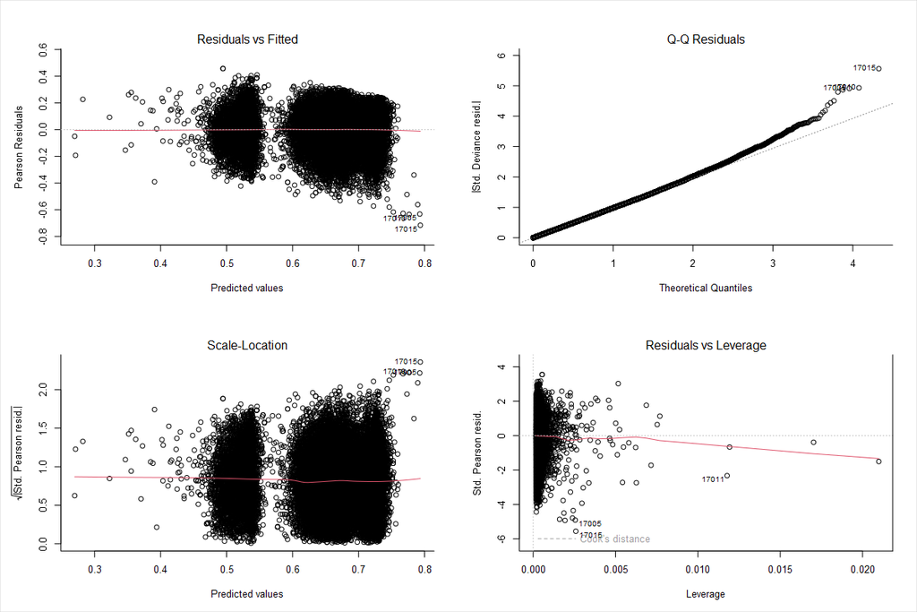

```r
par(mfrow=c(2,2), mar=c(5,5,4,2))
plot(spotify_full)
box(which="outer", col="lightgray")
```

Assumptions NOT met.

Cannot proceed with statistical inference.

## Dataset 2: Single Mother Households

**2. Consider the childcare cost dataset here: [TidyTuesday - Childare Costs](https://github.com/rfordatascience/tidytuesday/tree/master/data/2023/2023-05-09). We will be working with the number of single mother households with children under 6 years old (*h_under6_single_m*) as the outcome and median household income (*mhi_2018*), the unemployment rate for those 16 and older (*unr_16*), and the total number of households (*households*) as predictors. Go ahead and pull in the data.**

```r
childcare_costs <- readr::read_csv('https://raw.githubusercontent.com/rfordatascience/tidytuesday/master/data/2023/2023-05-09/childcare_costs.csv')

childcare_costs <- childcare_costs %>%
  select(h_under6_single_m, mhi_2018, unr_16, households) %>%
  na.omit()
```

**2a-i. Let’s do some data exploration. Explore and summarize the outcome, *h_under6_single_m*. (Yes, this is vague. You should look at summary statistics and at least one graph.)**

```r
# total number of rows
(total = noquote(paste0("Total Rows = ", nrow(childcare_costs))))
```

```
[1] Total Rows = 34565
```

```r
# quantiles
qts = quantile(childcare_costs$h_under6_single_m)
(qtsDF <- data.frame("quantile" = c("0%","25%","50%","75%","100%"),
                    "value" = unname(qts)))
```

```
  quantile  value
1       0%      0
2      25%    176
3      50%    489
4      75%   1298
5     100% 220530
```

```r
# boxplot stats
# whiskers extend to the most extreme data point which is no more than coef times the length of the box away from the box
bps = boxplot.stats(childcare_costs$h_under6_single_m, coef=4)$stats
# number of outliers when coef=4
bpsOut = length(boxplot.stats(childcare_costs$h_under6_single_m, coef=4)$out)
(bpsDF <- data.frame("boxplotStats" = c("extreme of lower whisker",
                                       "lower hinge",
                                       "median",
                                       "upper hinge",
                                       "extreme of upper whisker",
                                       "number of outliers"),
                    "value" = c(bps, bpsOut),
                    "cummulativePct" = c("1%","25%","50%","75%","93%","")))
```

```
              boxplotStats value cummulativePct
1 extreme of lower whisker     0             1%
2              lower hinge   176            25%
3                   median   489            50%
4              upper hinge  1298            75%
5 extreme of upper whisker  5779            93%
6       number of outliers  2443
```

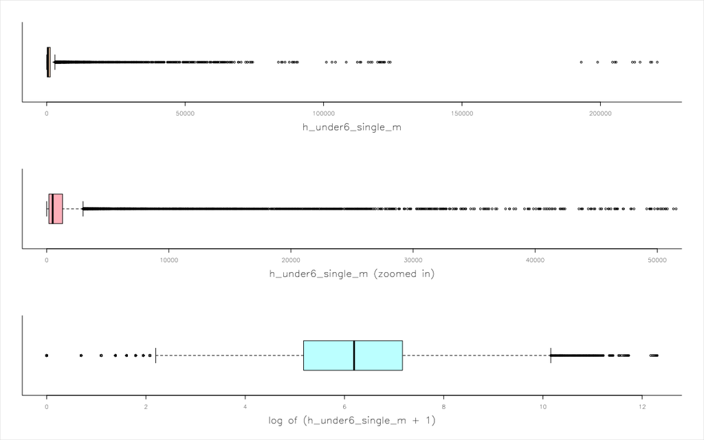

```r
# boxplots
options(scipen=n)
par(mfrow=c(3,1), mar=c(6,3,3,3), family="HersheySans", font=2, cex.lab=1.7)
boxplot(childcare_costs$h_under6_single_m, xlab="h_under6_single_m", horizontal=T, col="peachpuff1")
boxplot(childcare_costs$h_under6_single_m, ylim=c(0,50000), xlab="h_under6_single_m (zoomed in)", horizontal=T, col="lightpink1")
boxplot(log(childcare_costs$h_under6_single_m+1), xlab="log of (h_under6_single_m + 1)", horizontal=T, col="paleturquoise1")
box(which="outer", col="lightgray")
```

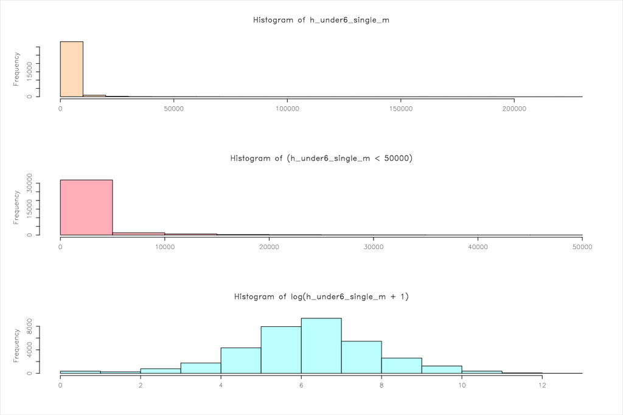

```r
# Histograms

par(mfrow=c(3,1), mar=c(6,6,6,3), cex.lab=1.3, cex.main=1.5, cex.axis=1.2)

# h_under6_single_m
hist(childcare_costs$h_under6_single_m,
     main="Histogram of h_under6_single_m",
     xlab="",
     col="peachpuff1")

# h_under6_single_m < 50000
hist(childcare_costs$h_under6_single_m[childcare_costs$h_under6_single_m < 50000],
     main="Histogram of (h_under6_single_m < 50000)",
     xlab="",
     col="lightpink1")

# log(h_under6_single_m + 1)
hist(log(childcare_costs$h_under6_single_m + 1),
     main="Histogram of log(h_under6_single_m + 1)",
     xlab="",
     col="paleturquoise1")

box(which="outer", col="lightgray")
```

**2a-ii. Let’s do some data exploration. Explore and summarize *mhi_2018*. (Yes, this is vague. You should look at summary statistics and at least one graph.)**

```r
mhi_2018 = childcare_costs$mhi_2018
summary(mhi_2018)
quantile(mhi_2018)
```

```
   Min. 1st Qu.  Median    Mean 3rd Qu.    Max.
  19842   41838   48506   50446   56201  136268
       0%       25%       50%       75%      100%
 19841.92  41838.03  48505.60  56200.95 136268.00
```

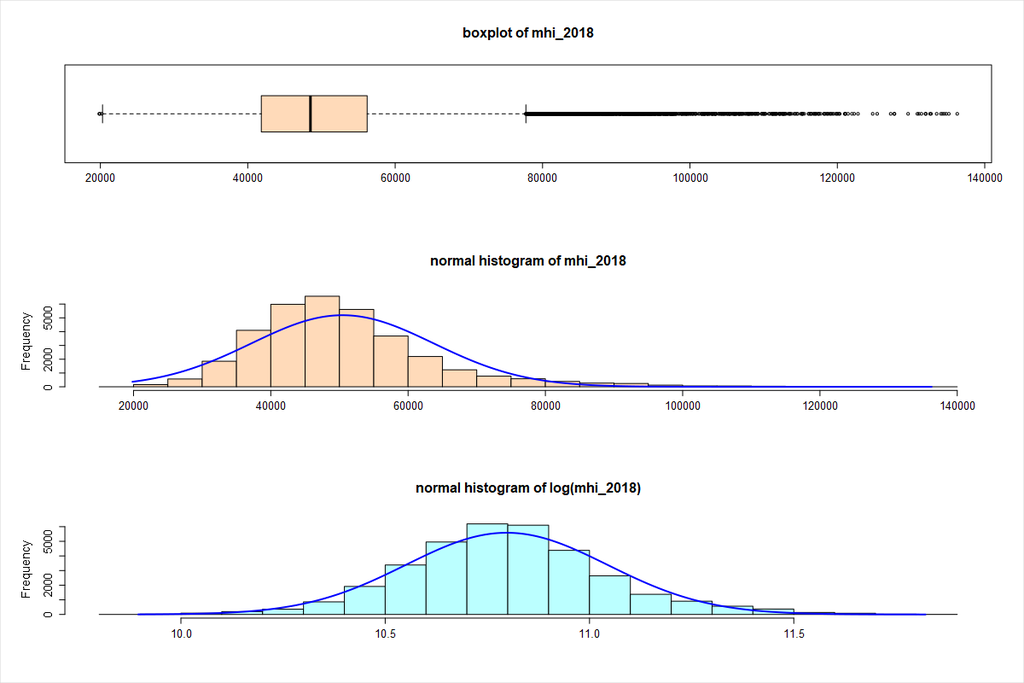

```r
par(mfrow=c(3,1), mar=c(6,6,6,3), cex.lab=1.3, cex.main=1.5, cex.axis=1.2)

boxplot(mhi_2018,
        main="boxplot of mhi_2018", xlab="",
        horizontal=T,
        col="peachpuff1")

rcompanion::plotNormalHistogram(mhi_2018,
                                main="normal histogram of mhi_2018", xlab="",
                                col="peachpuff1")

rcompanion::plotNormalHistogram(log(mhi_2018),
                                main="normal histogram of log(mhi_2018)", xlab="",
                                col="paleturquoise1")

box(which="outer", col="lightgray")
```

**2a-iii. Let’s do some data exploration. Explore and summarize *unr_16*. (Yes, this is vague. You should look at summary statistics and at least one graph.)**

```r
unr_16 = childcare_costs$unr_16
summary(unr_16)
quantile(unr_16)
```

```
   Min. 1st Qu.  Median    Mean 3rd Qu.    Max.
  0.000   5.100   7.050   7.466   9.350  36.110
   0%   25%   50%   75%  100%
 0.00  5.10  7.05  9.35 36.11
```

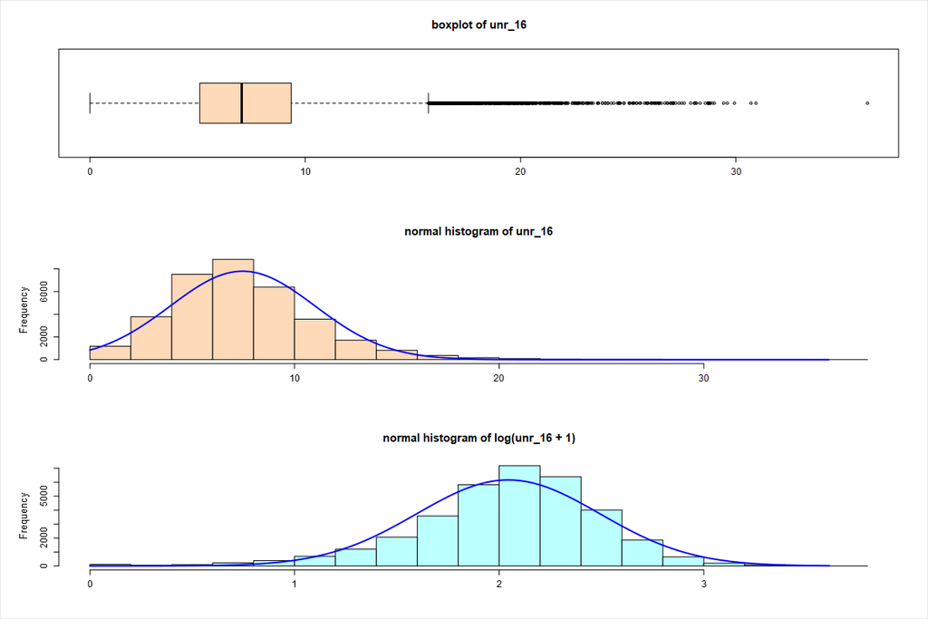

```r
par(mfrow=c(3,1), mar=c(5,6,5,3), cex.lab=1.2, cex.main=1.4, cex.axis=1.1)

boxplot(unr_16,
        main="boxplot of unr_16", xlab="",
        horizontal=T,
        col="peachpuff1")

rcompanion::plotNormalHistogram(unr_16,
                                main="normal histogram of unr_16", xlab="",
                                col="peachpuff1")

rcompanion::plotNormalHistogram(log(unr_16 + 1),
                                main="normal histogram of log(unr_16 + 1)", xlab="",
                                col="paleturquoise1")

box(which="outer", col="lightgray")
```

**2a-iv. Let’s do some data exploration. Explore and summarize *households*. (Yes, this is vague. You should look at summary statistics and at least one graph.)**

```r
households = childcare_costs$households
summary(households)
quantile(households)
```

```
   Min. 1st Qu.  Median    Mean 3rd Qu.    Max.
     22    4236    9812   36864   25495 3306109
     0%     25%     50%     75%    100%
     22    4236    9812   25495 3306109
```

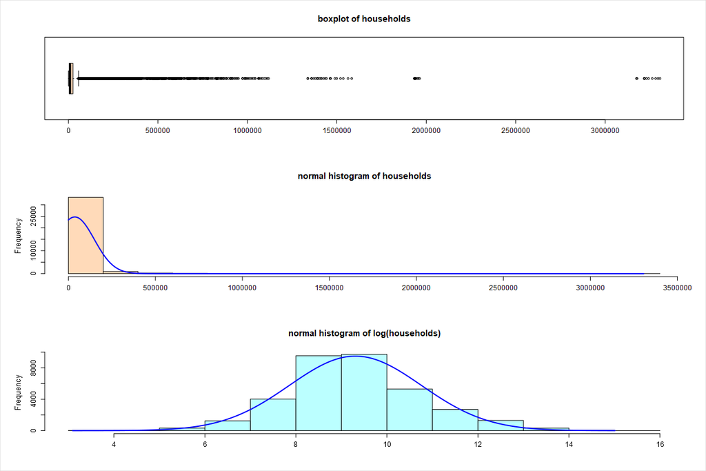

```r
par(mfrow=c(3,1), mar=c(5,6,5,3), cex.lab=1.2, cex.main=1.4, cex.axis=1.1)

boxplot(households,
        main="boxplot of households", xlab="",
        horizontal=T,
        col="peachpuff1")

rcompanion::plotNormalHistogram(households,
                                main="normal histogram of households", xlab="",
                                col="peachpuff1")

rcompanion::plotNormalHistogram(log(households),
                                main="normal histogram of log(households)", xlab="",
                                col="paleturquoise1")

box(which="outer", col="lightgray")
```

**2b. Consider modeling *h_under6_single_m* as a function of *mhi_2018*, *unr_16*, *households*, and the interaction between *unr_16* and *households*.**

**2b-i. What method (distribution) do you think is appropriate to apply here? Provide evidence to support your idea.**

```r
# NOT poisson
# mean does NOT equal variance
mean(childcare_costs$h_under6_single_m)
```

```
[1] 1992.25
```

```r
var(childcare_costs$h_under6_single_m)
```

```
[1] 49139181
```

Will use a normal distribution after applying the following transformations:

- log(h_under6_single_m + 1)
- log(households)

```r
childcare_costs <- childcare_costs %>%
  mutate(h_under6_single_m_LOG = log(h_under6_single_m + 1),
         households_LOG = log(households))
```

**2b-ii. What is the resulting model using the approach from 2b-i?**

```r
households_reduced <- glm(h_under6_single_m_LOG ~ 1, data=childcare_costs)

households_full <- glm(h_under6_single_m_LOG ~ mhi_2018 + unr_16 + households_LOG + unr_16:households_LOG,
                       data=childcare_costs)

summary(households_full)
```

```
Call:
glm(formula = h_under6_single_m_LOG ~ mhi_2018 + unr_16 + households_LOG +
    unr_16:households_LOG, data = childcare_costs)

Coefficients:
                        Estimate Std. Error t value Pr(>|t|)
(Intercept)           -4.989e+00  3.948e-02 -126.37   <2e-16 ***
mhi_2018              -1.258e-05  2.693e-07  -46.73   <2e-16 ***
unr_16                 1.692e-01  5.026e-03   33.67   <2e-16 ***
households_LOG         1.226e+00  4.852e-03  252.56   <2e-16 ***
unr_16:households_LOG -1.281e-02  5.809e-04  -22.06   <2e-16 ***
---
Signif. codes:  0 '***' 0.001 '**' 0.01 '*' 0.05 '.' 0.1 ' ' 1

(Dispersion parameter for gaussian family taken to be 0.2875152)

    Null deviance: 103701.6  on 34564  degrees of freedom
Residual deviance:   9936.5  on 34560  degrees of freedom
AIC: 55014

Number of Fisher Scoring iterations: 2
```

```r
anova(households_reduced, households_full, test="LRT")
```

```
Analysis of Deviance Table

Model 1: h_under6_single_m_LOG ~ 1
Model 2: h_under6_single_m_LOG ~ mhi_2018 + unr_16 + households_LOG +
    unr_16:households_LOG
  Resid. Df Resid. Dev Df Deviance  Pr(>Chi)
1     34564     103702
2     34560       9937  4    93765 < 2.2e-16 ***
---
Signif. codes:  0 '***' 0.001 '**' 0.01 '*' 0.05 '.' 0.1 ' ' 1
```

**2b-iii. Check the relevant assumptions of the model. Are we okay to proceed with statistical inference?**

```r
par(mfrow=c(1,1))
GGally::ggpairs(select(childcare_costs, h_under6_single_m_LOG, mhi_2018, unr_16, households_LOG))
```

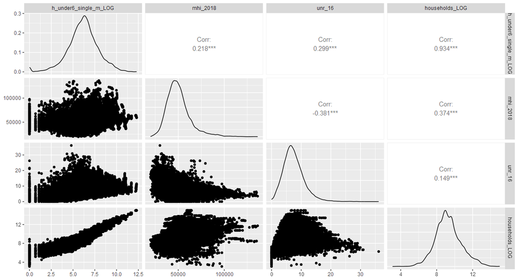

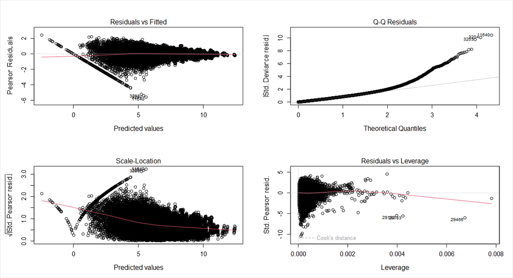

```r
par(mfrow=c(2,2), mar=c(5,5,4,2))
plot(households_full)
box(which="outer", col="lightgray")
```

Assumptions NOT met.

Cannot proceed with statistical inference.

```r
# extra code

childcare_costs$prop <- childcare_costs$h_under6_single_m / childcare_costs$households

childcare_prop_nb <- MASS::glm.nb(prop ~ mhi_2018 + unr_16 + mhi_2018:unr_16, data=childcare_costs)

summary(childcare_prop_nb)

dev.off()
par(mfrow=c(2,2))
plot(childcare_prop_nb, cex=0.5)
```

```
Call:
MASS::glm.nb(formula = prop ~ mhi_2018 + unr_16 + mhi_2018:unr_16,
    data = childcare_costs, init.theta = 70750.49349, link = log)

Coefficients:
                  Estimate Std. Error z value Pr(>|z|)
(Intercept)     -3.101e+00  2.079e-01 -14.918  < 2e-16 ***
mhi_2018        -8.403e-06  4.193e-06  -2.004  0.04505 *
unr_16           6.063e-02  2.086e-02   2.906  0.00366 **
mhi_2018:unr_16  9.628e-08  4.834e-07   0.199  0.84212
---
Signif. codes:  0 '***' 0.001 '**' 0.01 '*' 0.05 '.' 0.1 ' ' 1

(Dispersion parameter for Negative Binomial(70750.49) family taken to be 1)

    Null deviance: 10367  on 34564  degrees of freedom
Residual deviance: 10203  on 34561  degrees of freedom
AIC: 11863

Number of Fisher Scoring iterations: 1

              Theta:  70750
          Std. Err.:  247742
Warning while fitting theta: iteration limit reached

 2 x log-likelihood:  -11852.71
null device
          1
```

## Dataset 3: Scooby Doo

**3. Consider the Scooby Doo dataset here: [TidyTuesday - Scooby Doo](https://github.com/rfordatascience/tidytuesday/tree/master/data/2021/2021-07-13). We will be modeling if the culprit was arrested or not (*arrested*) as the outcome and will use snack data (*snack_fred*, *snack_daphnie*, *snack_velma*, *snack_shaggy*, *snack_scooby*), if Scrappy Doo appears in the episode (*scrappy_doo*), and the number of times “zoinks” is said in the episode (*zoinks*) in predictor creation. Go ahead and pull in the data.**

```r
scooby <- readr::read_csv('https://raw.githubusercontent.com/rfordatascience/tidytuesday/master/data/2021/2021-07-13/scoobydoo.csv')

scooby <- scooby %>%
  select(arrested, snack_fred, snack_daphnie, snack_velma, snack_shaggy, snack_scooby, scrappy_doo, zoinks) %>%
  na.omit()

str(scooby)
```

```
tibble [603 × 8] (S3: tbl_df/tbl/data.frame)
 $ arrested     : chr [1:603] "TRUE" "TRUE" "TRUE" "TRUE" ...
 $ snack_fred   : chr [1:603] "TRUE" "FALSE" "TRUE" "FALSE" ...
 $ snack_daphnie: chr [1:603] "FALSE" "FALSE" "FALSE" "TRUE" ...
 $ snack_velma  : chr [1:603] "FALSE" "TRUE" "FALSE" "FALSE" ...
 $ snack_shaggy : chr [1:603] "FALSE" "FALSE" "FALSE" "FALSE" ...
 $ snack_scooby : chr [1:603] "FALSE" "FALSE" "FALSE" "FALSE" ...
 $ scrappy_doo  : logi [1:603] FALSE FALSE FALSE FALSE FALSE FALSE ...
 $ zoinks       : chr [1:603] "1" "3" "1" "2" ...
```

```r
# zoinks should be integer, not char.. checking values
count(scooby, zoinks) %>% filter(zoinks=="NULL")
```

```
# A tibble: 1 × 2
  zoinks     n
  <chr>  <int>
1 NULL      32
```

```r
# remove rows that contain "NULL" values
scooby <- scooby %>%
  filter(arrested != "NULL",
         snack_fred != "NULL",
         snack_daphnie != "NULL",
         snack_velma != "NULL",
         snack_scooby != "NULL",
         zoinks != "NULL") %>%
  mutate(arrested = ifelse(arrested=="TRUE", 1, 0),
         snack_fred = ifelse(snack_fred=="TRUE", 1, 0),
         snack_daphnie = ifelse(snack_daphnie=="TRUE", 1, 0),
         snack_velma = ifelse(snack_velma=="TRUE", 1, 0),
         snack_shaggy = ifelse(snack_shaggy=="TRUE", 1, 0),
         snack_scooby = ifelse(snack_scooby=="TRUE", 1, 0),
         scrappy_doo = ifelse(scrappy_doo==TRUE, 1, 0),
         zoinks = as.numeric(zoinks))

str(scooby)
```

```
tibble [368 × 8] (S3: tbl_df/tbl/data.frame)
 $ arrested     : num [1:368] 1 1 1 1 1 1 1 0 1 1 ...
 $ snack_fred   : num [1:368] 1 0 1 0 0 1 0 0 0 0 ...
 $ snack_daphnie: num [1:368] 0 0 0 1 1 0 0 0 1 0 ...
 $ snack_velma  : num [1:368] 0 1 0 0 0 0 1 0 0 0 ...
 $ snack_shaggy : num [1:368] 0 0 0 0 0 0 0 0 0 0 ...
 $ snack_scooby : num [1:368] 0 0 0 0 0 0 0 0 0 0 ...
 $ scrappy_doo  : num [1:368] 0 0 0 0 0 0 0 0 0 0 ...
 $ zoinks       : num [1:368] 1 3 1 2 0 2 1 0 0 0 ...
```

**3a-i. Let’s do some data exploration. What are the possible responses in *arrested*? How many episodes fall into each possible outcome?**

```r
count(scooby, arrested)
```

```
# A tibble: 2 × 2
  arrested     n
     <dbl> <int>
1        0    41
2        1   327
```

**3a-ii. Let’s do some data management. Create a variable to indicate whether or not the culprit was arrested. Do not include responses that are not of interest.**

I think I might have already done this step when pulling in the data.

I removed any rows that contained “NULL” values.

**3a-iii. Let’s do some data management. Create a variable that indicates if there was a snack consumed during the episode. Your goal is to combine the snack data (*snack_fred*, *snack_daphnie*, *snack_velma*, *snack_shaggy*, *snack_scooby*) into a single yes/no variable.**

```r
scooby <- scooby %>%
  mutate(snack = ifelse(snack_fred+snack_daphnie+snack_velma+snack_shaggy+snack_scooby > 0, 1, 0))

count(scooby, snack)
```

```
# A tibble: 2 × 2
  snack     n
  <dbl> <int>
1     0   266
2     1   102
```

**3a-iv. Let’s do some data exploration. Find the overall mean number of zoinks (*zoinks*) per episode. Please note that some data management may (… or may not) be necessary.**

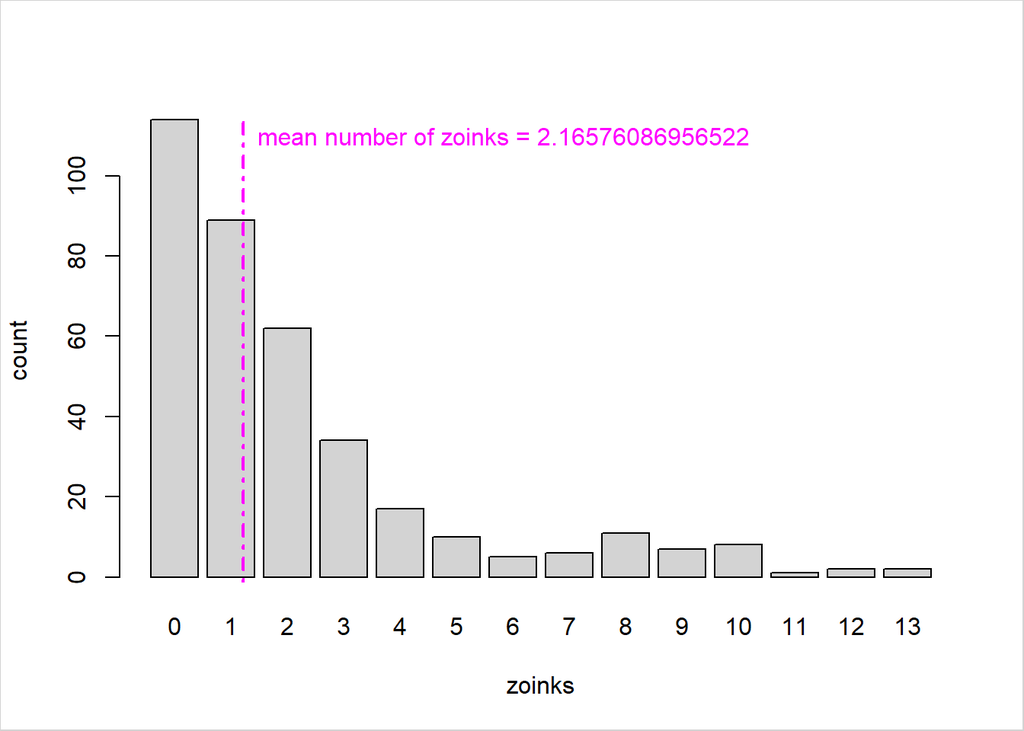

```r
xbar = mean(scooby$zoinks)
par(mfrow=c(1,1))
barplot(table(scooby$zoinks), xlab="zoinks", ylab="count", col="lightgray")
abline(v=xbar, col="magenta", lwd=2, lty=4)
text(x=xbar+0.3, y=110, col="magenta", paste0("mean number of zoinks = ", xbar), adj=0)
box(which="outer", col="lightgray")
```

**3a-v. Let’s do some data exploration. Find the number of episodes that Scrappy Doo appears in (*scrappy_doo*). Please note that some data management may (… or may not) be necessary.**

```r
length(scooby$scrappy_doo[scooby$scrappy_doo == 1])
```

```
[1] 22
```

Using the complete cases data set, scrappy doo only appears in 22 of the 368 total episodes, about 6%.

**3a-vi. Let’s do some data exploration. Find the number of episodes in which a snack is consumed (i.e., the variable you created in 3a-iii).**

```r
length(scooby$snack[scooby$snack == 1])
```

```
[1] 102
```

Using the complete cases data set, snacks were consumed in 102 of the 368 total episodes, about 28%.

**3a-vi. Let’s do some data exploration.**

- **What is the mean number of *zoinks* for episodes that resulted in an arrest and, separately, episodes that did not result in an arrest?**

```r
scooby %>%
  group_by(arrested) %>%
  summarise(zoinks_MEAN = mean(zoinks))
```

```
# A tibble: 2 × 2
  arrested zoinks_MEAN
     <dbl>       <dbl>
1        0        1.90
2        1        2.20
```

- **What number of episodes included a snack when the episode resulted in an arrest and, separately, when an episode did not result in an arrest?**

```r
scooby %>%
  group_by(arrested) %>%
  summarise(snack_SUM = sum(snack))
```

```
# A tibble: 2 × 2
  arrested snack_SUM
     <dbl>     <dbl>
1        0        11
2        1        91
```

```r
xtabs(~arrested+snack, data=scooby)
```

```
        snack
arrested   0   1
       0  30  11
       1 236  91
```

**3b. Consider modeling your indicator variable for *arrested* (yes/no only, from 3a-ii) as a function of the number of *zoinks*, if any *snack* was consumed, if Scrappy Doo was in the episode (*scrappy_doo*), and all two-way interaction terms (i.e., *zoinks:snack*, *zoinks:scrappy_doo*, and *snack:scrappy_doo*).**

**3b-i. What method (distribution) do you think is appropriate to apply here? Provide evidence to support your idea.**

Binomial Distribution.

Logistic Regression.

**3b-ii. What is the resulting model using the approach from 3b-i?**

```r
# full model
scooby_full <- glm(arrested ~ zoinks + snack + scrappy_doo + zoinks:snack + zoinks:scrappy_doo + snack:scrappy_doo, data=scooby, family="binomial"(link="logit"))

# reduced model (intercept only)
scooby_reduced <- glm(arrested ~ 1, data=scooby, family="binomial"(link="logit"))

# tests significance of the m1 regression line
anova(scooby_reduced, scooby_full, test="LRT")
```

```
Analysis of Deviance Table

Model 1: arrested ~ 1
Model 2: arrested ~ zoinks + snack + scrappy_doo + zoinks:snack + zoinks:scrappy_doo +
    snack:scrappy_doo
  Resid. Df Resid. Dev Df Deviance Pr(>Chi)
1       367     257.20
2       361     249.52  6   7.6848   0.2621
```

```r
# tests significance of each predictor
car::Anova(scooby_full, type=3)
```

```
Analysis of Deviance Table (Type III tests)

Response: arrested
                   LR Chisq Df Pr(>Chisq)
zoinks               1.5810  1     0.2086
snack                1.4925  1     0.2218
scrappy_doo          2.1508  1     0.1425
zoinks:snack         2.0263  1     0.1546
zoinks:scrappy_doo   0.1966  1     0.6575
snack:scrappy_doo    3.4566  1     0.0630 .
---
Signif. codes:  0 '***' 0.001 '**' 0.01 '*' 0.05 '.' 0.1 ' ' 1
```

```r
# tests significance of all terms (pairwise)
summary(scooby_full)
```

```
Call:
glm(formula = arrested ~ zoinks + snack + scrappy_doo + zoinks:snack +
    zoinks:scrappy_doo + snack:scrappy_doo, family = binomial(link = "logit"),
    data = scooby)

Coefficients:
                   Estimate Std. Error z value Pr(>|z|)
(Intercept)          1.8071     0.2361   7.655 1.94e-14 ***
zoinks               0.1159     0.1015   1.142    0.253
snack                0.6285     0.5339   1.177    0.239
scrappy_doo         17.6026   882.3746   0.020    0.984
zoinks:snack        -0.1988     0.1413  -1.407    0.159
zoinks:scrappy_doo  -0.4837     1.1357  -0.426    0.670
snack:scrappy_doo  -16.8578   882.3472  -0.019    0.985
---
Signif. codes:  0 '***' 0.001 '**' 0.01 '*' 0.05 '.' 0.1 ' ' 1

(Dispersion parameter for binomial family taken to be 1)

    Null deviance: 257.20  on 367  degrees of freedom
Residual deviance: 249.52  on 361  degrees of freedom
AIC: 263.52

Number of Fisher Scoring iterations: 16
```

**3c. Consider modeling your indicator variable for *arrested* (yes/no only, from 3a-ii) as a function of the number of *zoinks*, if any *snack* was consumed, and if Scrappy Doo was in the episode (*scrappy_doo*).**

```r
# full model
scooby_full_2 <- glm(arrested ~ zoinks + snack + scrappy_doo, data=scooby, family="binomial"(link="logit"))

# tests significance of the m1 regression line
anova(scooby_reduced, scooby_full_2, test="LRT")
```

```
Analysis of Deviance Table

Model 1: arrested ~ 1
Model 2: arrested ~ zoinks + snack + scrappy_doo
  Resid. Df Resid. Dev Df Deviance Pr(>Chi)
1       367     257.20
2       364     255.64  3   1.5618   0.6681
```

```r
# tests significance of each predictor
car::Anova(scooby_full_2, type=3)
```

```
Analysis of Deviance Table (Type III tests)

Response: arrested
            LR Chisq Df Pr(>Chisq)
zoinks       0.25079  1     0.6165
snack        0.01009  1     0.9200
scrappy_doo  1.10543  1     0.2931
```

```r
# tests significance of all terms (pairwise)
summary(scooby_full_2)
```

```
Call:
glm(formula = arrested ~ zoinks + snack + scrappy_doo, family = binomial(link = "logit"),
    data = scooby)

Coefficients:
            Estimate Std. Error z value Pr(>|z|)
(Intercept)  1.95972    0.22439   8.734   <2e-16 ***
zoinks       0.03263    0.06665   0.490    0.624
snack        0.03806    0.37969   0.100    0.920
scrappy_doo  0.95912    1.04453   0.918    0.358
---
Signif. codes:  0 '***' 0.001 '**' 0.01 '*' 0.05 '.' 0.1 ' ' 1

(Dispersion parameter for binomial family taken to be 1)

    Null deviance: 257.20  on 367  degrees of freedom
Residual deviance: 255.64  on 364  degrees of freedom
AIC: 263.64

Number of Fisher Scoring iterations: 5
```

**3c-i. Why are you applying the same distribution as in 3b-i?**

The type of outcome variable didn’t change, it is still binary.

We only dropped the interaction terms.

**3c-ii. What is the resulting model using the approach from 3b-i?**

```r
round(summary(scooby_full)$coef,2)
```

```
                   Estimate Std. Error z value Pr(>|z|)
(Intercept)            1.81       0.24    7.65     0.00
zoinks                 0.12       0.10    1.14     0.25
snack                  0.63       0.53    1.18     0.24
scrappy_doo           17.60     882.37    0.02     0.98
zoinks:snack          -0.20       0.14   -1.41     0.16
zoinks:scrappy_doo    -0.48       1.14   -0.43     0.67
snack:scrappy_doo    -16.86     882.35   -0.02     0.98
```

**3d. Use leave-one-out cross validation to determine if the model from 3b-ii or 3c-ii is “better” for the data. Make sure you state which model is best and why.**

```r
# 3b-ii CV Prediction Error
set.seed(3874)
boot::cv.glm(scooby, scooby_full)$delta
```

```
[1] 0.1040016 0.1039945
```

```r
# 3c-ii CV Prediction Error
set.seed(3874)
boot::cv.glm(scooby, scooby_full_2)$delta
```

```
[1] 0.1005474 0.1005451
```

**Which model fits better?**

3c-ii

The model from 3c-ii has lower error & is also the simpler model :)